# Red Wine Quality

Tyler Borras

## Introduction

> This data set contains physicochemical and sensory data for the red variant of Portuguese “Vinho Verde” wine. The dataset contains 11 independent variables and one dependent variable. The dependent variable is the median of the subjective “quality” of the wine as gauged by at least three experts.

## Univariate Plots Section

> This section will begin with summary statistics for the data and then the univariate plots.

```
Observations: 1,599
Variables: 13
$ X                    <int> 1, 2, 3, 4, 5, 6, 7, 8, 9, 10, 11, 12, 13...
$ fixed.acidity        <dbl> 7.4, 7.8, 7.8, 11.2, 7.4, 7.4, 7.9, 7.3, ...
$ volatile.acidity     <dbl> 0.700, 0.880, 0.760, 0.280, 0.700, 0.660,...
$ citric.acid          <dbl> 0.00, 0.00, 0.04, 0.56, 0.00, 0.00, 0.06,...
$ residual.sugar       <dbl> 1.9, 2.6, 2.3, 1.9, 1.9, 1.8, 1.6, 1.2, 2...
$ chlorides            <dbl> 0.076, 0.098, 0.092, 0.075, 0.076, 0.075,...
$ free.sulfur.dioxide  <dbl> 11, 25, 15, 17, 11, 13, 15, 15, 9, 17, 15...
$ total.sulfur.dioxide <dbl> 34, 67, 54, 60, 34, 40, 59, 21, 18, 102, ...
$ density              <dbl> 0.9978, 0.9968, 0.9970, 0.9980, 0.9978, 0...
$ pH                   <dbl> 3.51, 3.20, 3.26, 3.16, 3.51, 3.51, 3.30,...
$ sulphates            <dbl> 0.56, 0.68, 0.65, 0.58, 0.56, 0.56, 0.46,...
$ alcohol              <dbl> 9.4, 9.8, 9.8, 9.8, 9.4, 9.4, 9.4, 10.0, ...
$ quality              <int> 5, 5, 5, 6, 5, 5, 5, 7, 7, 5, 5, 5, 5, 5,...
```

```
       X          fixed.acidity   volatile.acidity  citric.acid
 Min.   :   1.0   Min.   : 4.60   Min.   :0.1200   Min.   :0.000
 1st Qu.: 400.5   1st Qu.: 7.10   1st Qu.:0.3900   1st Qu.:0.090
 Median : 800.0   Median : 7.90   Median :0.5200   Median :0.260
 Mean   : 800.0   Mean   : 8.32   Mean   :0.5278   Mean   :0.271
 3rd Qu.:1199.5   3rd Qu.: 9.20   3rd Qu.:0.6400   3rd Qu.:0.420
 Max.   :1599.0   Max.   :15.90   Max.   :1.5800   Max.   :1.000
 residual.sugar     chlorides       free.sulfur.dioxide
 Min.   : 0.900   Min.   :0.01200   Min.   : 1.00
 1st Qu.: 1.900   1st Qu.:0.07000   1st Qu.: 7.00
 Median : 2.200   Median :0.07900   Median :14.00
 Mean   : 2.539   Mean   :0.08747   Mean   :15.87
 3rd Qu.: 2.600   3rd Qu.:0.09000   3rd Qu.:21.00
 Max.   :15.500   Max.   :0.61100   Max.   :72.00
 total.sulfur.dioxide    density             pH          sulphates
 Min.   :  6.00       Min.   :0.9901   Min.   :2.740   Min.   :0.3300
 1st Qu.: 22.00       1st Qu.:0.9956   1st Qu.:3.210   1st Qu.:0.5500
 Median : 38.00       Median :0.9968   Median :3.310   Median :0.6200
 Mean   : 46.47       Mean   :0.9967   Mean   :3.311   Mean   :0.6581
 3rd Qu.: 62.00       3rd Qu.:0.9978   3rd Qu.:3.400   3rd Qu.:0.7300
 Max.   :289.00       Max.   :1.0037   Max.   :4.010   Max.   :2.0000
    alcohol         quality
 Min.   : 8.40   Min.   :3.000
 1st Qu.: 9.50   1st Qu.:5.000
 Median :10.20   Median :6.000
 Mean   :10.42   Mean   :5.636
 3rd Qu.:11.10   3rd Qu.:6.000
 Max.   :14.90   Max.   :8.000
```

> There are twelve columns of data and the index column which will be dropped. all columns are of type double except the dependent variable “quality”, which is an integer. The features are measured using the following:

#### Input variables (based on physicochemical tests):

1. fixed acidity (tartaric acid - g / dm^3)
2. volatile acidity (acetic acid - g / dm^3)
3. citric acid (g / dm^3)
4. residual sugar (g / dm^3)
5. chlorides (sodium chloride - g / dm^3
6. free sulfur dioxide (mg / dm^3)
7. total sulfur dioxide (mg / dm^3)
8. density (g / cm^3)
9. pH
10. sulphates (potassium sulphate - g / dm3)
11. alcohol (% by volume)
- Output variable (based on sensory data):
12. quality (score between 0 and 10)

(Cortez et al., 2009)

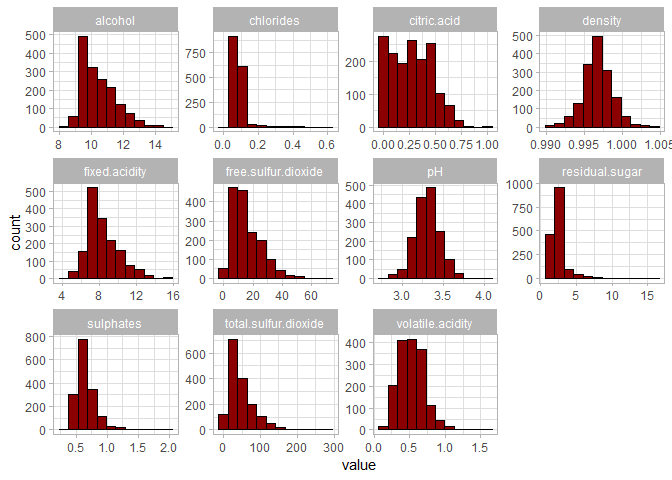

> A Quick view of the independent variables to get abetter idea of the distributions.

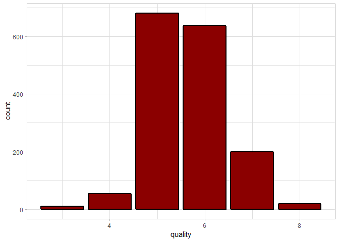

```
    quality
 Min.   :3.000
 1st Qu.:5.000
 Median :6.000
 Mean   :5.636
 3rd Qu.:6.000
 Max.   :8.000
```

> The distribution of the quality appears to be normal, with a range of three to eight and a median of 6. There are very few samples for 3, 4, or 8.

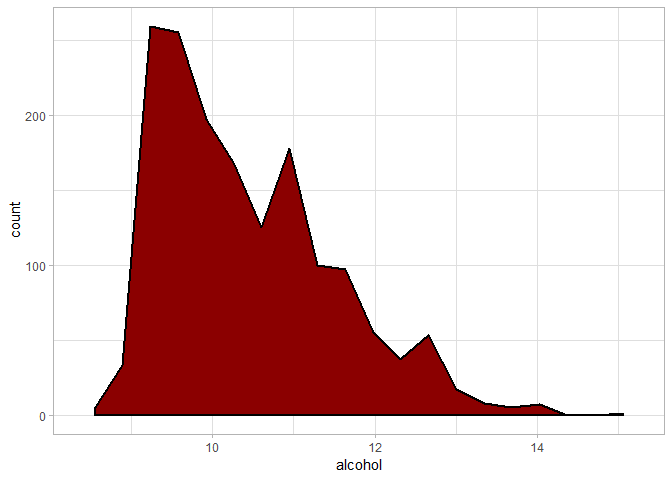

```
    alcohol
 Min.   : 8.40
 1st Qu.: 9.50
 Median :10.20
 Mean   :10.42
 3rd Qu.:11.10
 Max.   :14.90
```

> Alcohol is skewed right and peaks around 9.5 with another smaller peak at 11. The minimum of 8.4, maximum of 14.9, and median of 10.2 are all suprising because most wines, that I have seen, have very little variance in alcohol content.

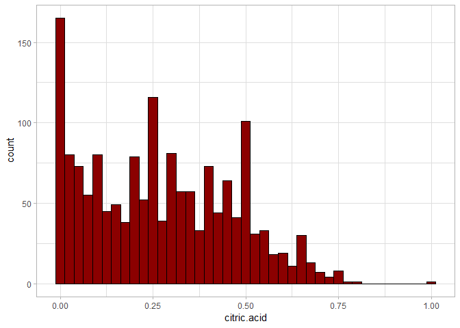

```
  citric.acid
 Min.   :0.000
 1st Qu.:0.090
 Median :0.260
 Mean   :0.271
 3rd Qu.:0.420
 Max.   :1.000
```

> A closer look at citric acid reveals peaks in descending order at 0, 0.25, and 0.50. The first quartile is at 0.09 due to a large number of wines with 0 citric acid.

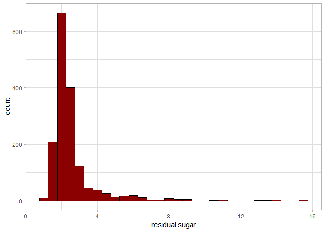

```
 residual.sugar
 Min.   : 0.900
 1st Qu.: 1.900
 Median : 2.200
 Mean   : 2.539
 3rd Qu.: 2.600
 Max.   :15.500
```

> Residual sugar is highly skewed to the right with a median of 2.2 and a range of 0.9 to 15.5. Most of the wines fall into a very small range of sugar, the IQR is 1.9-2.6. I don’t think this is going to be a good predictor due to the lack of variance.

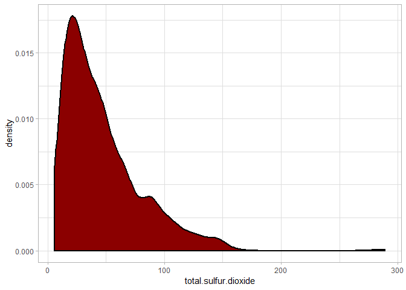

```
 total.sulfur.dioxide
 Min.   :  6.00
 1st Qu.: 22.00
 Median : 38.00
 Mean   : 46.47
 3rd Qu.: 62.00
 Max.   :289.00
```

> Total sulfer dioxide is also highly right skewed with a median of 38 and a range of 6 to 289.

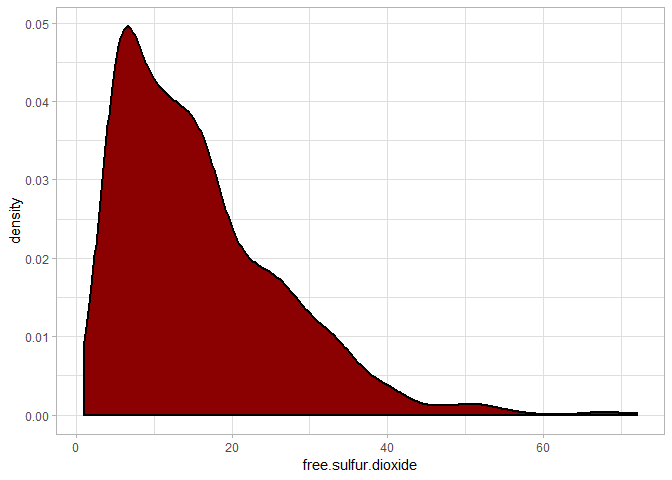

```
 free.sulfur.dioxide
 Min.   : 1.00
 1st Qu.: 7.00
 Median :14.00
 Mean   :15.87
 3rd Qu.:21.00
 Max.   :72.00
```

> Free sulfer dioxide has a similar distribution to total sulfur dioxide, with a lower range of 1 to 72 with a median of 14.

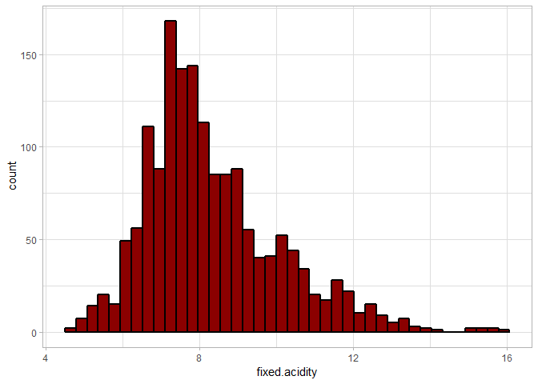

```
 fixed.acidity
 Min.   : 4.60
 1st Qu.: 7.10
 Median : 7.90
 Mean   : 8.32
 3rd Qu.: 9.20
 Max.   :15.90
```

> Fixed acidity is normally distributed and skewed right

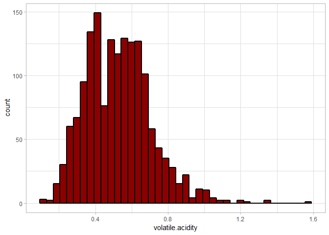

```
 volatile.acidity
 Min.   :0.1200
 1st Qu.:0.3900
 Median :0.5200
 Mean   :0.5278
 3rd Qu.:0.6400
 Max.   :1.5800
```

```r
d <- ggplot(df, aes(volatile.acidity))
d + geom_histogram( fill = 'darkred', color = 'black', size = 1, bins = 40)
```

> Volatile acidity has a similar distribution to fixed acidity with a range of 0.12 to 1.58 versus the range of 4.6 to 15.9 of fixed acidity

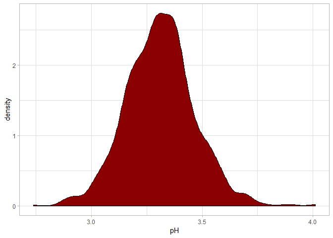

```
       pH
 Min.   :2.740
 1st Qu.:3.210
 Median :3.310
 Mean   :3.311
 3rd Qu.:3.400
 Max.   :4.010
```

> pH is normally distributed with a mean and median of 3.31

# Univariate Analysis

### What is the structure of your dataset?

> There are eleven independent variables and one dependent variable. All variables are of type double except the dependent variable “quality”, which is an integer. There are 1,599 samples. Quality is normally distributed with a range of 3 to 8 and a median of 6.

### What is/are the main feature(s) of interest in your dataset?

> Quality is the dependent variable so it is the main feature of interest.

### What other features in the dataset do you think will help support your

### investigation into your feature(s) of interest?

> If I had to speculate at this point in the analysis, I would say alcohol, and all of the acidity based variables including citric acid will be the most important supporting features.

### Did you create any new variables from existing variables in the dataset?

> I have not created any variables at this point of the investigation.

### Of the features you investigated, were there any unusual distributions?

> I consider citric acid to be unusual because so many samples have zero citric acid. It seems unusual that wine from the same region made with the same process would be void of a substance, while other wines contain a small amount. Alcohol was also strange due to its large variance, I think it may be a good predictor.

# Bivariate Plots Section

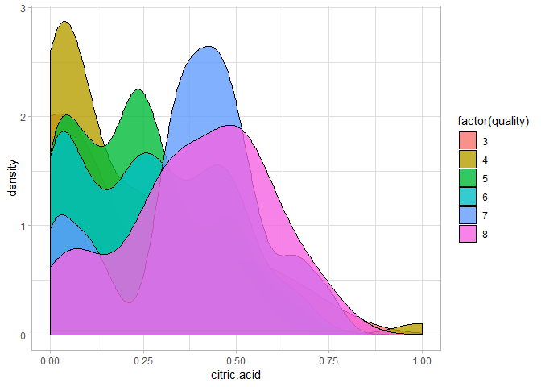

> I started with citric acid because I thought it was the most unusual distribution of the univariate plots. This graph shows that low quality wines, those with quality of 3 or 4, generally have low, or zero, citric acid content. The wines with quality of 5 or 6 generally have a moderate citric acid content. High quality wines, with aquality of 7 or 8, generally have the highest citric acid content. Citric acid definitely has a correlation with quality.

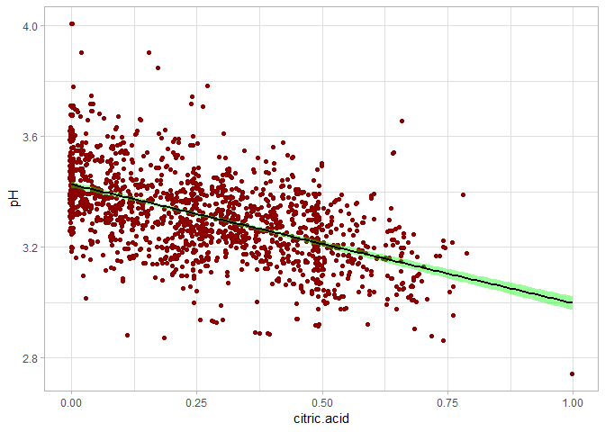

> Taking a closer look at citric acid reveals an inverse relationship with pH. This was expected as a lower pH indicates higher acidity. Next, I would like to see the relationship between pH and quality.

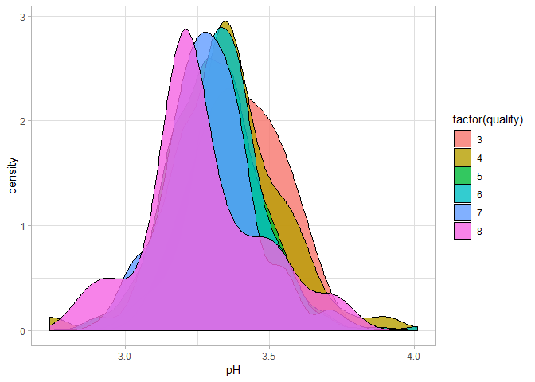

> While not as distinct as the citric acid correlation to quality, pH does appear to have an inverse correlation with quality which confirms the findings of the two previous graphs.

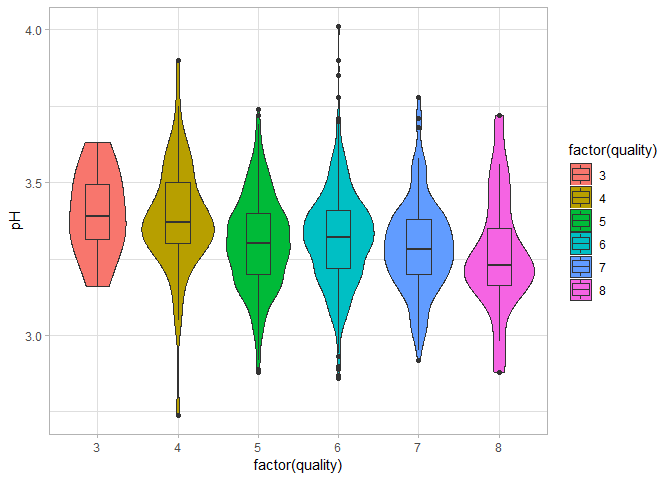

> A closer look at pH reveals that wines with a quality of 3 have the highest median pH and a very small range. The median and the interquartile range trend lower as the quality increases. I would like a closer look at the other acidic features to determine if they contribute to the quality as well.

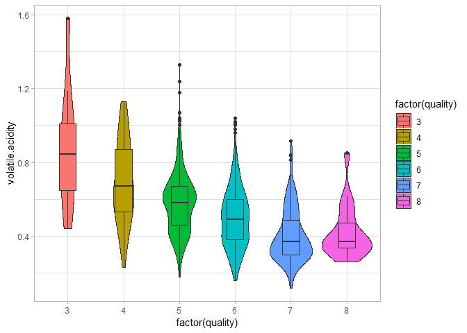

> Both the mean and the IQR for volatile acidity decreases as the quality increases. While citric acid increases, volatile acidity decreases with quality, possibly explaining why the trend for pH is more subtle.

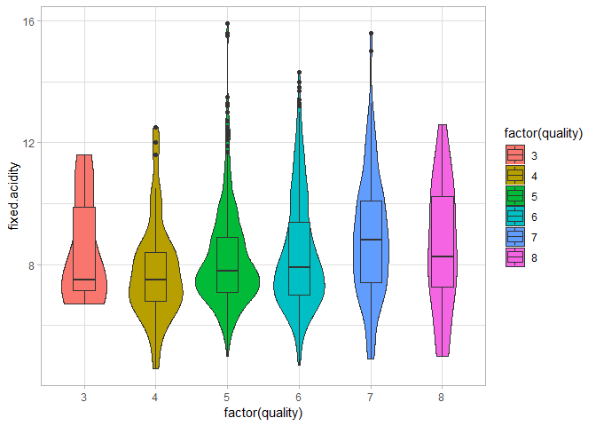

> Fixed acidity does not appear to have any significant affect on quality.

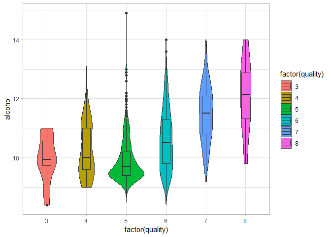

> The next interesting featurefrom the univariate analysis was alcohol. Alcohol content in wines with a quality of 3, 4, or 5 tends to be low, while wines with a quality of 6, 7, or 8 generally have higher alcohol and a distinct upward trend. The wines with a quality of 5 have a large range, and actually have a lower median and IQR than the lower quality wines. It appears as though there is some other factor other than alcohol in lower quality wines that affects the quality. High quality wines, 7 and 8, have a significantly higher median and IQR than the other qualities.

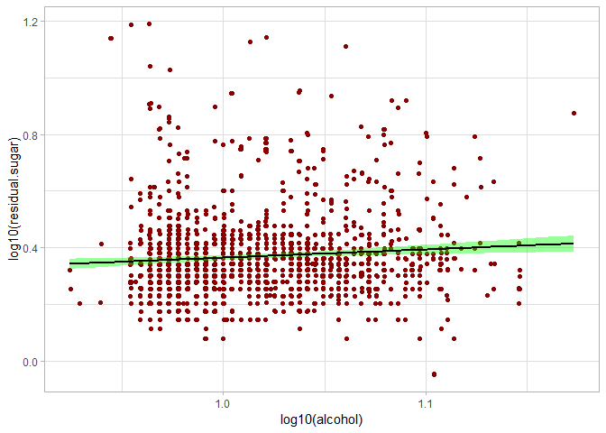

> I thought sugar may play a part in the alcohol content, but despite their direct relationship in the fermentation process, there appears to be very little, if any, correlation between alcohol and residual sugar.

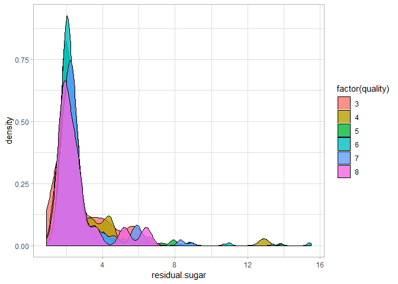

> Residual sugar does not vary significantly for different quality ratings. This confirms the observations made in the univariate section.

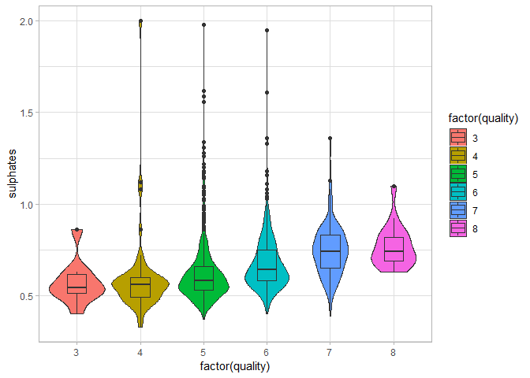

> Higher levels of sulphates are present in the higher quality wines, with the median and IQR increasing with quality. Another interesting observation is the small range of sulphates for wines with quality 3 or 8, and a large range for wines in the middle.

# Bivariate Analysis

### Talk about some of the relationships you observed in this part of the

### investigation. How did the feature(s) of interest vary with other features

### in the dataset?

> Citric acid, volatile acidity, sulphates, pH, and alcohol all had a correlation with quality. Low, or zero, citric acid levels were present in low-quality wines, while higher quality wines generally had higher levels of citric acid. Volatile acidity and pH had an inverse relationship with quality.

### Did you observe any interesting relationships between the other features

### (not the main feature(s) of interest)?

> Citric acid had an inverse correlation with pH which makes sense due to the increase in acid. Alcohol and residual sugar had very little, if any, correlation which was suprising due to their relationship in the fermentation process.

### What was the strongest relationship you found?

> Alcohol was a definative relationship where the median high quality wines had two percent more alcohol than a low quality wine. The high quality wines had an alcohol content on par with most common red wines, around 12%. The lowest quality wines had a median alcohol content below 10%, which is much lower than other typical red wines. This could be due to a shorter fermentation time or less sugar to ferment.

# Multivariate Plots Section

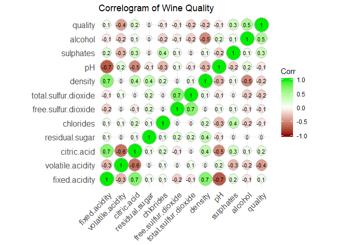

> I am starting off with a correlogram using the default pearson correlation coefficients, which reinforces some of the previous observations. Alcohol has the strongest positive correlation with quality folowed by sulphates. Volatile acidity had the strongest negative correlation. Citric acid has a strong negative correlation with pH. Density has several strong correlations worth exploring.

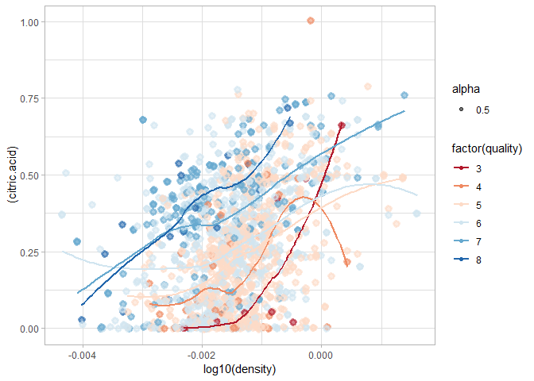

> Citric acid is one of the features from the bivariate section that correlated with quality. This chart shows citric acid charted with density. Density had several strong correlations in the correlogram including those with citric acid and to a lesser extent quality. This chart shows higher quality wines generally have higher citric acid and a lower density.

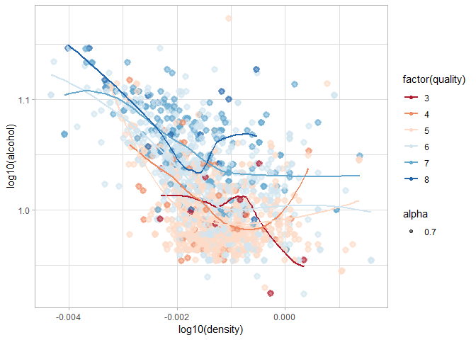

> After looking at this chart I realized that a high alcohol content would necessarily lead to a lower density due to the relatively low density of alcohol. There is a very distinct trend of high quality wines in the second quadrant and lower quality wines in the fourth quadrant. This collaborates previous evidence of high quality wines having higher alcohol content and lower density.

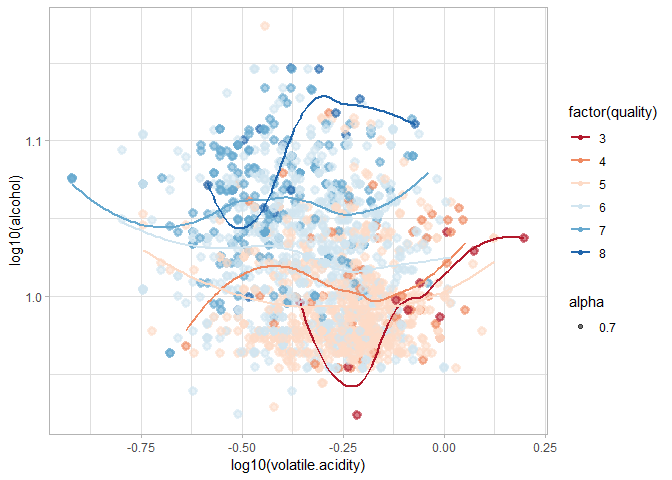

> Volatile acidity and alcohol had the highest correlation to quality in the correlogram, which supported the evidence from the bivariate plots. This relationship can be seen here. The weak relationship between alcohol and volatile acidity is not evident in this graph.

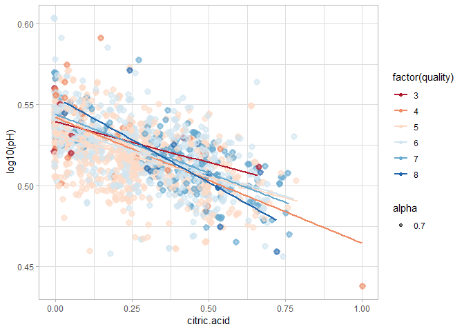

> A strong negative correlation between citric acid and pH was demonstrated in the bivatiate section, here we see this relationship and the correlation to quality. Most high quality wines are high in citric acid and of lower pH.

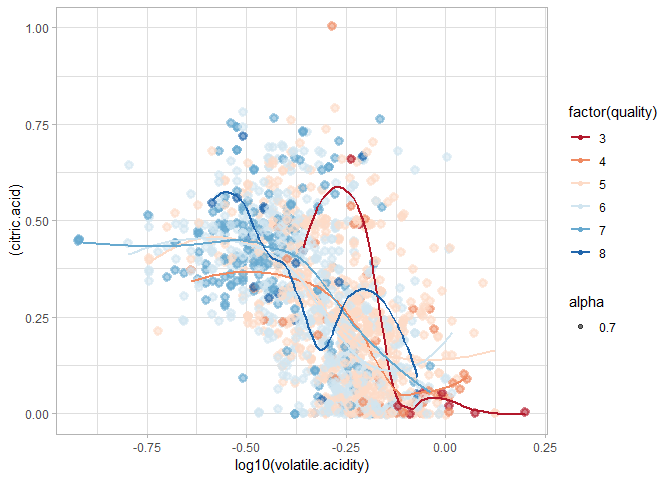

> Volatile acidity and citric acid are two of the features from the bivariate section and the correlogram that showed a strong corrrelation to quality. This graph shows the lowest quality wines grouped in the fourth quadrant with very low or zero citric acid and high volatile acidity.

# Multivariate Analysis

### Talk about some of the relationships you observed in this part of the

### investigation. Were there features that strengthened each other in terms of

### looking at your feature(s) of interest?

> The pearson correlation coefficients showed the strongest correlations with quality were from alcohol, citric acid, and sulphates on the positive side and volitile acidity on the negative side. Alcohol showed had the highest Pearson coefficient with a value of +0.5. Density and alcohol were plotted together due to the negative correlation and a relationship between low density, high alcohol and high quality was seen. The plot of citric acid and density also shows the low density wines being of higher quality.

### Were there any interesting or surprising interactions between features?

> Citric acid and volitile acidity showed a very distinct relationship of high citric acid and low volatile acidity with the quality of wine.

### OPTIONAL: Did you create any models with your dataset? Discuss the

### strengths and limitations of your model.

> No models were created

# Final Plots and Summary

### Plot One

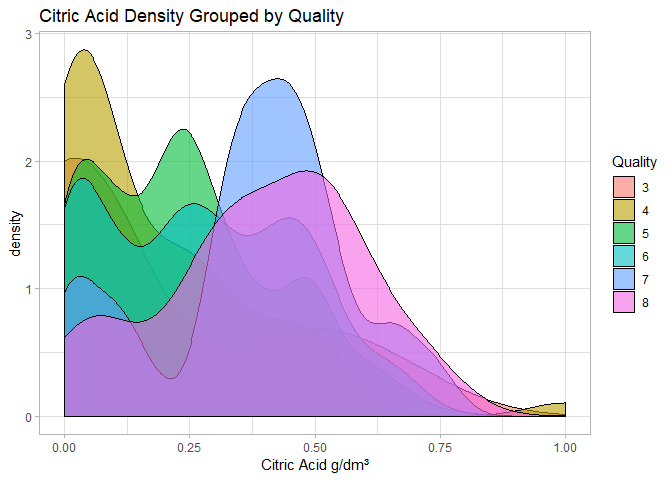

### Description One

> The density plot of citric acid was interesting because it showed the correlation to quality based on the density of the observations which allowed for a balanced perspective of the groups with very few observations.

### Plot Two

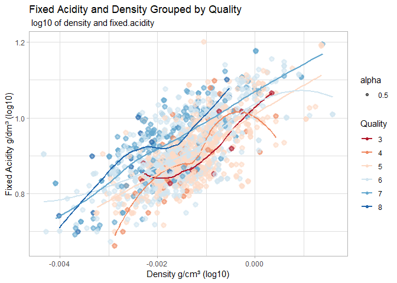

### Description Two

> The near linear relationship between two seemingly unrelated features made this an interesting plot. It also shows the relationship of quality to these features maintains a near linear relationship.

### Plot Three

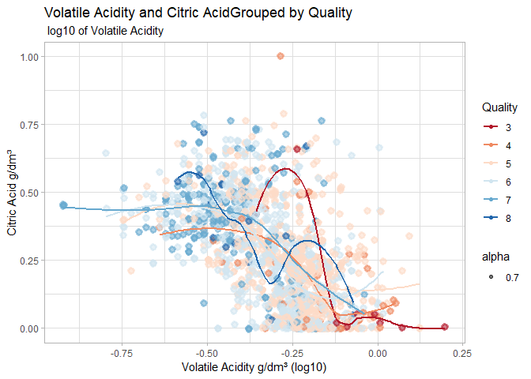

### Description Three

> This chart shows nearly all low quality observations grouped in quadrant IV with higher quality wines near quadrand II. I think these variables alone could produce a resonable estimation of the quality of wine.

## Reflection

> The red wine dataset was an interesting dataset of physicochemical and sensory data for the red variant of Portuguese “Vinho Verde” wine. I was able to find some interesting correlations between the various features and quality. Alcohol , volatile acidity, and citric acid were all correlated to wine quality.I think one of the more difficlut things in this dataset is the narrow IQR of 5-6, for quality. There were very few observations on either extreme which made visualizing counts by color difficult. I was able to overcome this by using density plots in some situations and by using muted colors for the more common values on other plots. Two things I found suprising in this dataset were the large variance of alcohol, and the lack of citric acid in some samples. I think more samples on the extremes of quality would add a lot to the data. As is the dataset does not contain any samples of 1, 2, 9, or 10, and very few samples for 3, 4, and 8. I beleive modeling the data using a support vector machine as mentioned in the wine quality info text would add to the analysis.

## Resources

- http://r-statistics.co/Top50-Ggplot2-Visualizations-MasterList-R-Code.html
- https://stackoverflow.com
- https://drsimonj.svbtle.com/quick-plot-of-all-variables
- http://www.sthda.com/english/wiki/ggcorrplot-visualization-of-a-correlation-matrix-using-ggplot2
- https://rstudio.com/wp-content/uploads/2016/03/rmarkdown-cheatsheet-2.0.pdf
- https://bookdown.org/yihui/rmarkdown/html-document.html

## References

P. Cortez, A. Cerdeira, F. Almeida, T. Matos and J. Reis. Modeling wine preferences by data mining from physicochemical properties. In Decision Support Systems, Elsevier, 47(4):547-553. ISSN: 0167-9236.